# GLM in the Bayesian Framework

## Introduction

- Last week, we discussed the beginnings of general linear models.
- Overall question: what is the relationship between $Y$ (outcome) and $X$ (predictor)?

$$y_i = \beta_0 + \beta_1 x_1 + \beta_2 x_2 + \cdots + \beta_k x_k + \varepsilon_i$$

## R Packages Needed

- To follow today’s lecture, please load the following packages:

```r
library(tidyverse)
library(bayesrules)
library(bayesplot)
library(tidybayes)
library(ggpubr)
library(rstanarm)
library(janitor)
library(broom.mixed)
```

## Evaluating the Model

- We will now learn how to evaluate *how good* our regression model is.
- How fair is the model?
  - How was the data collected?
  - By whom and for what purpose?
  - How might the results of the data collection or analysis impact individuals and society?
  - What biases might be baked into the analysis?

## Evaluating the Model

- We want to now learn how to evaluate *how good* our regression model is.
- How wrong is the model?
  - Are our assumptions reasonable?
  - Is the predictor set appropriate and complete?
- How accurate are the posterior predictive models?
  - How far are the posterior predictive models from reality?

## Working Example

- Consider our example before the break, the Capital Bikeshare data.
- We simulated under the following model:

$$\begin{align*}
Y_i | \beta_0, \beta_1, \sigma &\overset{\text{ind}}{\sim} N(\beta_0 + \beta_1X_i,\sigma^2) \\
\beta_{0\text{c}} &\sim N(5000, 1000^2) \\
\beta_{1\text{c}} &\sim N(100, 40^2) \\
\sigma &\sim \text{Exp}(0.0008)
\end{align*}$$

## Is the Model Fair?

- **How was the data collected?**
  - It is reasonable to assume that the bikeshare was collected electronically.
  - We do not have individual-level information, only aggregated ride data.
- **By whom and for what purpose was the data collected?**
  - It is reasonable for a bike sharing company to track data such as number of rides in a day.
  - The company is likely doing this to make evidence-based business decisions.

## Is the Model Fair?

- **How might the results of the analysis, or the data collection itself, impact individuals and society?**
  - Because there is no individual-level information, this will not negatively impact customers.
  - Improving the service might help reduce car traffic in D.C. - this is good!
- Note!
  - Just because we cannot imagine societal impacts does not mean that none exist.
  - It’s critical to recognize our perspective based on our experiences.
  - How can we truly determine the impacts?
    - We would need to engage with the company and its community.

## Is the Model Fair?

- **What biases might be baked into this analysis?**
  - The data is only for one company.
    - Other bikeshare companies may have different usage patterns.
  - The data is only for one city.
    - Other cities may have different usage patterns for bikeshare.
    - Other cities will have different weather patterns.
  - How generalizable is our model?

## Is the Model Fair?

- **How do I approach thinking about bias in analysis?**
  - Who is and is not represented in the data?
  - What assumptions were made about the data?
  - What assumptions are made about the truth/the population?
  - Is the analysis method appropriate for the question posed?
    - e.g., did they use logistic regression for a binary outcome?
  - Were there any “reaching” assumptions made in order to complete the analysis?
    - e.g., assuming data is MCAR when it is likely MAR or MNAR.
    - e.g., assuming independent observations when there is likely correlation.
  - Are the results stated appropriately? (vs. overstated)
    - Are broad, sweeping generalizations made from a narrow dataset?

## How Wrong is the Model?

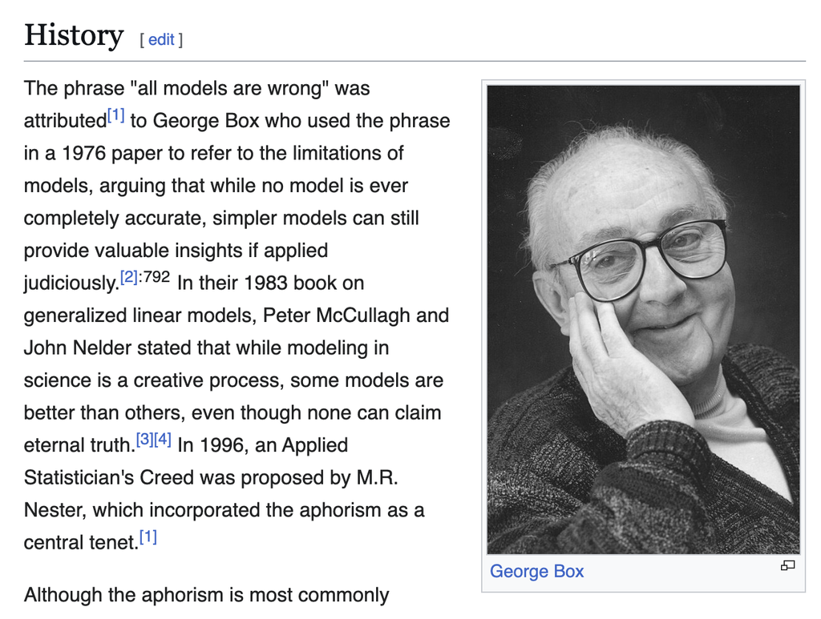

## How Wrong is the Model?

- Recall the data model,

$$Y_i | \beta_0, \beta_1, \sigma \overset{\text{ind}}{\sim} N(\beta_0 + \beta_1X_i,\sigma^2)$$

- What are the assumptions on our model?
  - The observed data, $Y_i$, is independent of other observed data, $Y_j$ for $i \neq j$.
  - $Y$ can be written as a linear function of $X$, $\mu=\beta_0 + \beta_1 X$.
  - At any $X$, $Y$ varys normally around $\mu$ with consistent variability, $\sigma$.

## How Wrong is the Model?

- **The observed data, $Y_i$, is independent of other observed data, $Y_j$ for $i \neq j$.**
  - We can technically test for this, but it is not often employed by statisticians.
  - Instead, we rely on knowledge of the data collection process.
  - If the data collection process suggests dependence, we should consider a different model.
    - e.g., a modeling approach that will account for the correlation between observations.

## How Wrong is the Model?

- **The observed data, $Y_i$, is independent of other observed data, $Y_j$ for $i \neq j$.**
- In this example, the data are daily counts of bike rides.
  - There is inherently some correlation – the ridership today is likely correlated to the ridership yesterday.
  - However, this can be explained by the time of year and features associated with the time of year, like temperature.
  - We should ask ourselves if it’s reasonable to assume that the temperature cancels out the time correlation.
- **“Reasonable” does not mean “perfect,” but instead, “good enough to proceed.”**

## How Wrong is the Model?

- Returning to our bike data, we can look at the scatterplot of temperature and number of rides.

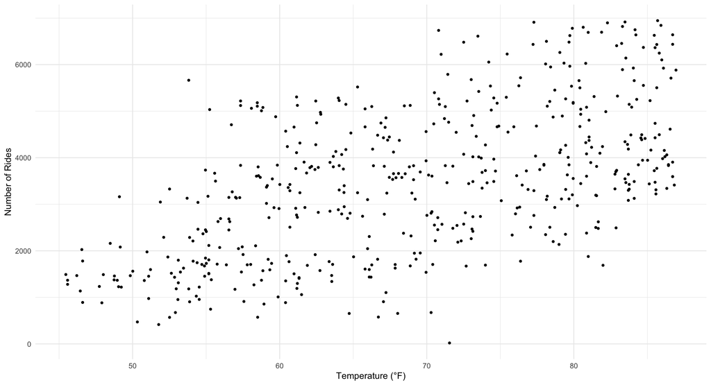

## How Wrong is the Model?

- We can overlay a line of best fit using `geom_smooth(method = "lm")`.

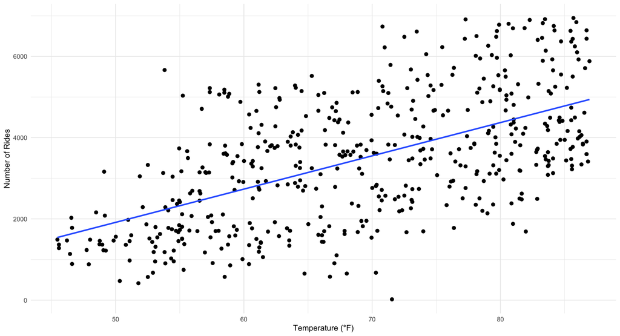

## How Wrong is the Model?

- Or we can overlay a locally estimated scatterplot smoothing (LOESS) line using `geom_smooth()`.

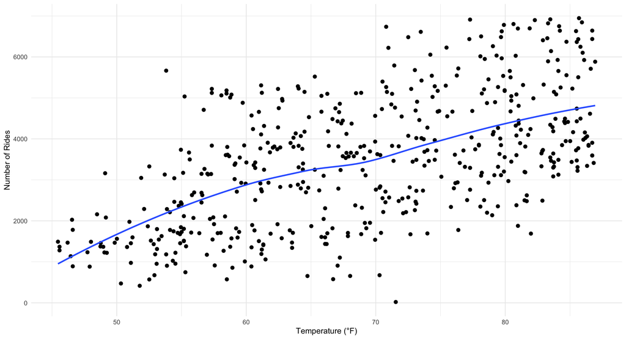

## How Wrong is the Model?

- How different are the two lines?

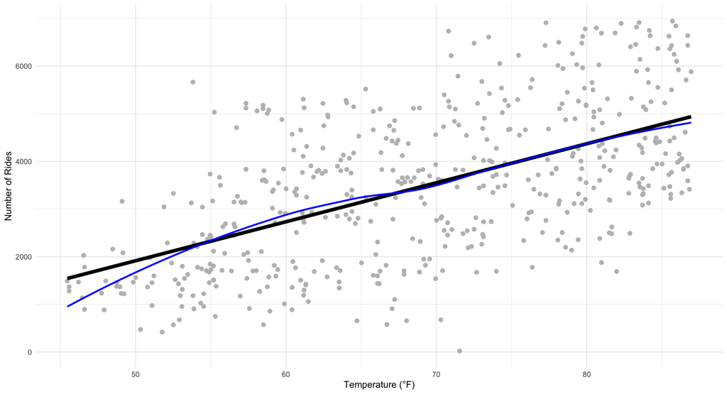

## How Wrong is the Model?

- When does “visualization” suggest that a linear model is not appropriate?
  - Does the LOESS line deviates substantially from the linear line?
  - Here, we see that the LOESS line is fairly close to the linear line.
  - Thus, it is reasonable to assume a linear relationship between $X$ and $Y$.
- Are there “issues” with this approach?
  - When we have more than one predictor, yes.
  - We are only visualizing one predictor at a time.
  - We will need to use other tools to assess linearity in multiple regression.

## How Wrong is the Model?

- To examine linearity in multiple regression, we will perform a posterior predictive check.
- If the combined model assumptions are reasonable, then our posterior model should be able to simulate ridership data that’s similar to the original 500 rides observations.

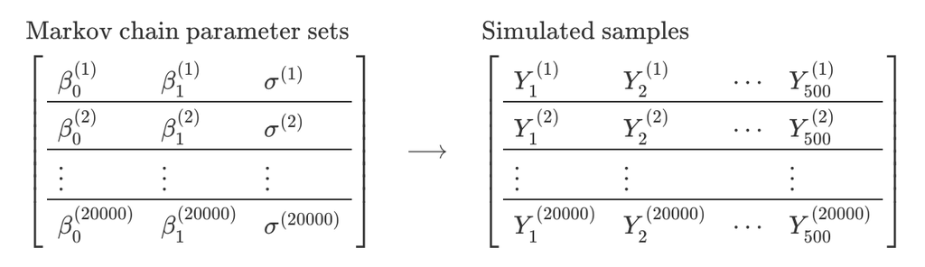

- For each of the 20,000 posterior plausible parameter sets, $\{\beta_0, \beta_1, \sigma\}$, we can predict ridership data from the observed temperature data.
  - This gives us 20,000 unique datasets of predicted ridership, each with $n=500$.

## How Wrong is the Model?

- Recall our analysis,

```r
bike_model <- stan_glm(rides ~ temp_feel,
                       data = bikes,
                       family = gaussian,
                       prior_intercept = normal(5000, 1000, autoscale = TRUE),
                       prior = normal(100, 40, autoscale = TRUE),
                       prior_aux = exponential(0.0008, autoscale = TRUE), # sigma
                       chains = 4,
                       iter = 5000*2,
                       seed = 84735)
```

## How Wrong is the Model?

- Recall our analysis,

```r
tidy(bike_model, conf.int = TRUE)
```

| term | estimate | std.error | conf.low | conf.high |
| --- | --- | --- | --- | --- |
| (Intercept) | -2177.92731 | 357.204567 | -2771.30965 | -1593.26616 |
| temp_feel | 81.88632 | 5.071117 | 73.48454 | 90.30665 |

- This gives the model,

$$\hat{y} = -2177.9 + 81.9x \ \ \ \to \ \ \ \hat{\text{rides}} = -2177.9 + 81.9\text{temp}$$

## How Wrong is the Model?

- How do we perform the posterior predictive check?
- The `pp_check()` function plots a number of the corresponding simulated datasets.

```r
pp_check(bike_model,
         nreps=50,
         seed = 84735) +
  xlab("Number of Rides") +
  theme_minimal()
```

## How Wrong is the Model?

- The `pp_check()` function plots a number of the corresponding simulated datasets.

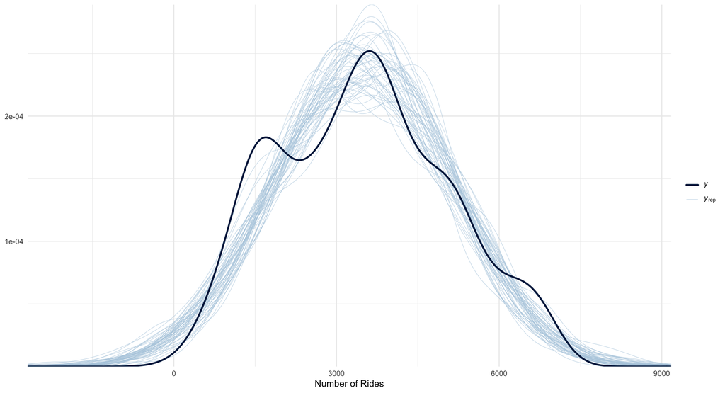

## How Accurate are Posterior Predictive Models?

- Although we are interested in predicting the future, we can begin by evaluating how well it predicts the data that was used to build the model.
- We can use the `posterior_predict()` function to generate posterior predictive summaries to either our data or new data.

```r
predictions <- posterior_predict(bike_model, newdata=bikes, seed = 84735)
dim(predictions)
```

```
[1] 20000   500
```

- We have 20,000 posterior predictive datasets, each with 500 predicted ride counts.

## How Accurate are Posterior Predictive Models?

- We can also use the `ppc_intervals()` function to visualize the posterior predictive intervals for each observation.

```r
ppc_intervals(bikes$rides,
              yrep = predictions,
              x = bikes$temp_feel,
              prob = 0.5,
              prob_outer = 0.95) +
  theme_minimal()
```

## How Accurate are Posterior Predictive Models?

- We can also use the `ppc_intervals()` function to visualize the posterior predictive intervals for each observation.

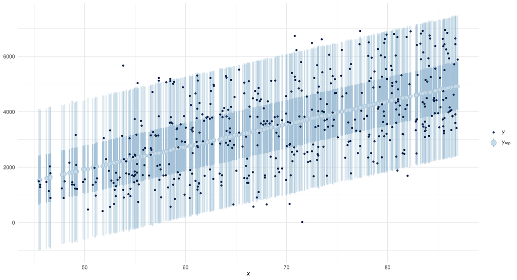

## How Accurate are Posterior Predictive Models?

- Let $Y_1, Y_2, ..., Y_n$ denote $n$ observed outcomes. Each $Y_i$ has a corresponding posterior predictive model with mean $Y_i'$ and standard deviation $\text{sd}_i$
- Median Absolute Error (MAE): the typical difference between the observed value and posterior predictive mean.

$$\text{MAE} = \text{median} | Y_i - Y_i'|$$

- Scaled Median Absolute Error (MAE scaled): the typical difference between the observed value and posterior predictive mean.

$$\text{MAE scaled} = \text{median} \frac{| Y_i - Y_i'|}{\text{sd}_i}$$

## How Accurate are Posterior Predictive Models?

- Let $Y_1, Y_2, ..., Y_n$ denote $n$ observed outcomes. Each $Y_i$ has a corresponding posterior predictive model with mean $Y_i'$ and standard deviation $\text{sd}_i$
- Within 50: Proportion of observed values that fall within their 50% posterior prediction interval.
- Within 95: Proportion of observed values that fall within their 95% posterior prediction interval.
- We get these four values out of the `prediction_summary()` function,

```r
set.seed(84735)
prediction_summary(bike_model, data = bikes)
```

| mae | mae_scaled | within_50 | within_95 |
| --- | --- | --- | --- |
| 993.3983 | 0.7720912 | 0.438 | 0.968 |

## How Accurate are Posterior Predictive Models?

- Let’s now interpret these values.

```r
set.seed(84735)
prediction_summary(bike_model, data = bikes)
```

| mae | mae_scaled | within_50 | within_95 |
| --- | --- | --- | --- |
| 993.3983 | 0.7720912 | 0.438 | 0.968 |

## How Accurate are Posterior Predictive Models?

- Looking at these side by side,

| mae | mae_scaled | within_50 | within_95 |
| --- | --- | --- | --- |
| 993.3983 | 0.7720912 | 0.438 | 0.968 |

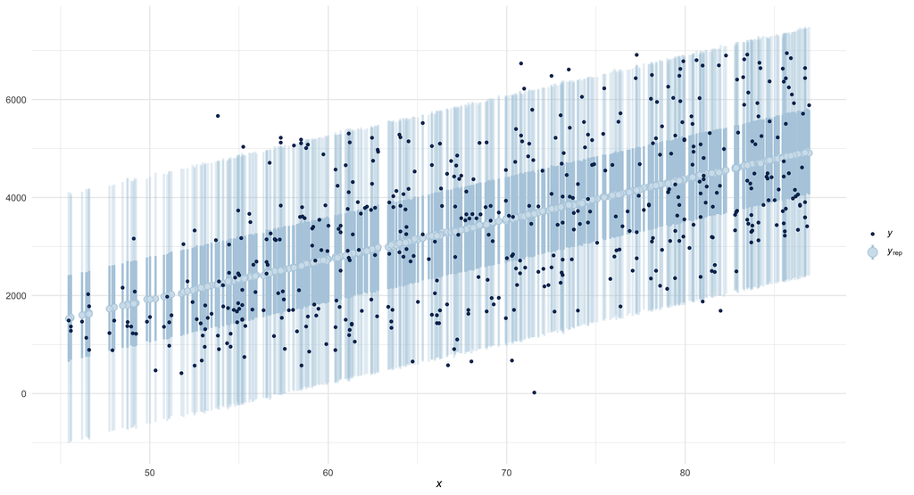

## How Accurate are Posterior Predictive Models?

- What is our final conclusion? Does our Bayesian model produce accurate predictions?
- Unfortunately, the answer is subjective and dependent on context.
  - Is an MAE of 990 rides acceptable for the business?
  - Is having only 43.8% of observations within the 50% prediction interval acceptable?
- Per usual, we are just the statisticians. The business must decide what is acceptable.

## How Accurate are Posterior Predictive Models?

- How can we improve the model’s posterior predictive accuracy?
  - Add additional predictors or terms (e.g., interactions) to the model.
  - Consider different distributions for the outcome variable.
    - e.g., Poisson, negative binomial, binomial, etc.
  - Collect more data.
    - This is always the cheeky answer.

## Wrap Up

- Today we covered Bayesian general linear regression and basic evaluation of regression models.
  - Is the model fair?
  - How wrong is the model?,
  - How accurate are the posterior predictive models?
- We as statisticians provide the numbers, but our collaborator decides what is acceptable in terms of “good enough” for the model’s predictive accuracy.